# Practical Machine Learning Project

Awadnr

March 7, 2019

# Background

Using devices such as Jawbone Up, Nike FuelBand, and Fitbit it is now possible to collect a large amount of data about personal activity relatively inexpensively. In this project, my goal will be to use data from accelerometers on the belt, forearm, arm, and dumbell of 6 participants. They were asked to perform barbell lifts correctly and incorrectly in 5 different ways. More information is available from the website here: http://groupware.les.inf.puc-rio.br/har

# Data

Training data: https://d396qusza40orc.cloudfront.net/predmachlearn/pml-training.csv

Test data: https://d396qusza40orc.cloudfront.net/predmachlearn/pml-testing.csv

The data for this project come from this source: http://groupware.les.inf.puc-rio.br/har.

## Summary of Technique

In order to accomplish the goal of this project the data will be loaded, cleaned and explored to discover structure and summary statistics. Once preliminary diagnostics and setup are complete, the seed will be set at 1234. In order to ensure accuracy and cross validate results the data will be partitioned and subsampled to accomidate test and train data set models. Once both the decision tree model and rand forest model are complete the accuracy will be compaired and final decision will be made on which model to use.

Loading Libraries then exploring and cleaning data

```r
library(dplyr)
library(caret)
library(rpart.plot)
library(randomForest)
library(e1071)

train <- read.csv("pml-training.csv", na.strings=c("NA","#DIV/0!", ""))
test <- read.csv("pml-testing.csv", na.strings=c("NA","#DIV/0!", ""))

summary(train)
summary(test)
str(train)
str(test)
```

Cleaning and partitioning data for use in models by creating 2 subsets of the training set.

```r
set.seed(1234)

# Removing all columns with NAs
train <-train[,colSums(is.na(train)) == 0]
test <-test[,colSums(is.na(test)) == 0]

# Removing extraneous columns for simplicity
train <-train[,-c(1:7)]
test <-test[,-c(1:7)]

# Partitioning data
training_set <- createDataPartition(y=train$classe, p=0.75, list=FALSE)
train_set <- train[training_set, ]
test_set <- train[-training_set, ]
```

# Prediction Model: Decision Tree

Creating and Plotting the Decision Tree

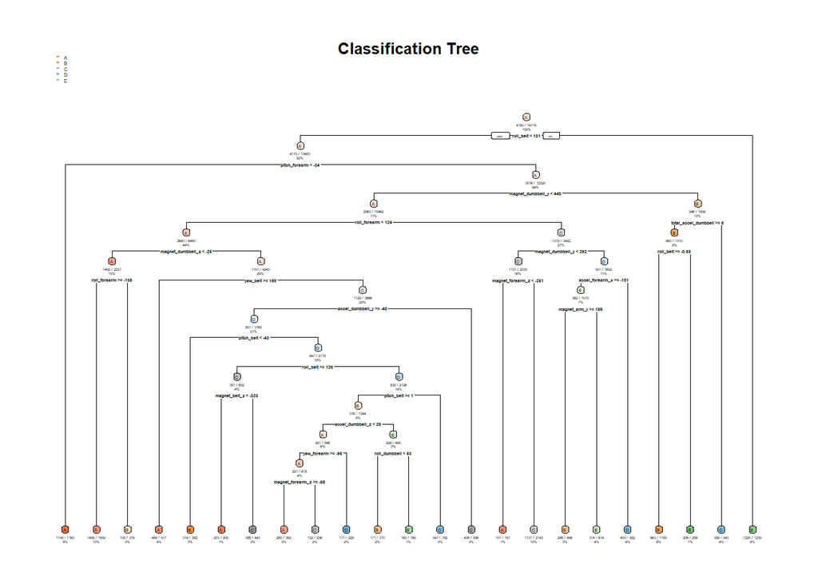

```r
pred_model <- rpart(classe ~ ., data = train_set, method ="class")

rpart.plot(pred_model, main = "Classification Tree",
           extra = 102, under = TRUE, faclen = 0)
```

Testing Results

```r
mod_pred <- predict(pred_model, test_set, type = "class")

confusionMatrix(mod_pred, test_set$classe)
```

```
## Confusion Matrix and Statistics
##
##           Reference
## Prediction    A    B    C    D    E
##          A 1235  157   16   50   20
##          B   55  568   73   80  102
##          C   44  125  690  118  116
##          D   41   64   50  508   38
##          E   20   35   26   48  625
##
## Overall Statistics
##
##                Accuracy : 0.7394
##                  95% CI : (0.7269, 0.7516)
##     No Information Rate : 0.2845
##     P-Value [Acc > NIR] : < 2.2e-16
##
##                   Kappa : 0.6697
##  Mcnemar's Test P-Value : < 2.2e-16
##
## Statistics by Class:
##
##                      Class: A Class: B Class: C Class: D Class: E
## Sensitivity            0.8853   0.5985   0.8070   0.6318   0.6937
## Specificity            0.9307   0.9216   0.9005   0.9529   0.9678
## Pos Pred Value         0.8356   0.6469   0.6313   0.7247   0.8289
## Neg Pred Value         0.9533   0.9054   0.9567   0.9296   0.9335
## Prevalence             0.2845   0.1935   0.1743   0.1639   0.1837
## Detection Rate         0.2518   0.1158   0.1407   0.1036   0.1274
## Detection Prevalence   0.3014   0.1790   0.2229   0.1429   0.1538
## Balanced Accuracy      0.9080   0.7601   0.8537   0.7924   0.8307
```

# Prediction Model: Random Forest

Running Randomn Forest

```r
ran_for <- randomForest(classe ~. , data = train_set)
```

Testing Results

```r
for_pred <- predict(ran_for, test_set, type = "class", method="class")

confusionMatrix(for_pred, test_set$classe)
```

```
## Confusion Matrix and Statistics
##
##           Reference
## Prediction    A    B    C    D    E
##          A 1395    3    0    0    0
##          B    0  943   10    0    0
##          C    0    3  844    5    0
##          D    0    0    1  799    0
##          E    0    0    0    0  901
##
## Overall Statistics
##
##                Accuracy : 0.9955
##                  95% CI : (0.9932, 0.9972)
##     No Information Rate : 0.2845
##     P-Value [Acc > NIR] : < 2.2e-16
##
##                   Kappa : 0.9943
##  Mcnemar's Test P-Value : NA
##
## Statistics by Class:
##
##                      Class: A Class: B Class: C Class: D Class: E
## Sensitivity            1.0000   0.9937   0.9871   0.9938   1.0000
## Specificity            0.9991   0.9975   0.9980   0.9998   1.0000
## Pos Pred Value         0.9979   0.9895   0.9906   0.9988   1.0000
## Neg Pred Value         1.0000   0.9985   0.9973   0.9988   1.0000
## Prevalence             0.2845   0.1935   0.1743   0.1639   0.1837
## Detection Rate         0.2845   0.1923   0.1721   0.1629   0.1837
## Detection Prevalence   0.2851   0.1943   0.1737   0.1631   0.1837
## Balanced Accuracy      0.9996   0.9956   0.9926   0.9968   1.0000
```

# Which Model to Use?

The Random Forest model performed better than Decision Tree model. The Decision Tree model accuracy was 0.739 (95% CI: (0.727, 0.752)) where the Random Forest model was 0.995 (95% CI: (0.993, 0.997)). The Random Forest model will be used to test.

# Submission

```r
test_set_pred <- predict(ran_for, test, type="class")
test_set_pred
```

```
##  1  2  3  4  5  6  7  8  9 10 11 12 13 14 15 16 17 18 19 20
##  B  A  B  A  A  E  D  B  A  A  B  C  B  A  E  E  A  B  B  B
## Levels: A B C D E
```